# GREENGrid Household Electricity Demand Data Circuit Extract Test: Heat Pump

Ben Anderson (b.anderson@soton.ac.uk, `@dataknut`)

Last run at: 2018-11-19 14:38:56

# 1 About

## 1.1 Report circulation:

- Public - analysis for use in ICEERB 2018 presentation.

## 1.2 License

## 1.3 Citation

If you wish to use any of the material from this report please cite as:

- Anderson, B. (2018) GREENGrid Household Electricity Demand Data Circuit Extract Test: Heat Pump. [Centre for Sustainability](http://www.otago.ac.nz/centre-sustainability/), University of Otago: Dunedin, New Zealand.

This work is (c) 2018 the University of Southampton.

## 1.4 History

- [Report history](https://github.com/CfSOtago/GREENGrid/commits/master/analysis/heatPumpAnalysis/heatPumpAnalysis.Rmd)

## 1.5 Requirements:

This report uses the safe version of the grid spy 1 minute data which has been processed using the code in https://github.com/CfSOtago/GREENGridData/tree/master/dataProcessing/gridSpy. It also assumes you have already run the example circuit extraction script using circuit = Heat Pump.

## 1.6 Support

This work was supported by:

- The [University of Otago](https://www.otago.ac.nz/);
- The [University of Southampton](https://www.southampton.ac.uk/);
- The New Zealand [Ministry of Business, Innovation and Employment (MBIE)](http://www.mbie.govt.nz/) through the [Renewable Energy and the Smart Grid (GREEN Grid)](https://www.otago.ac.nz/centre-sustainability/research/energy/otago050285.html) project;
- [SPATIALEC](http://www.energy.soton.ac.uk/tag/spatialec/) - a [Marie Skłodowska-Curie Global Fellowship](http://ec.europa.eu/research/mariecurieactions/about-msca/actions/if/index_en.htm) based at the University of Otago’s [Centre for Sustainability](http://www.otago.ac.nz/centre-sustainability/staff/otago673896.html) (2017-2019) & the University of Southampton’s Sustainable Energy Research Group (2019-2020).

We do not ‘support’ the code but if you notice a problem please check the issues on our [repo](https://github.com/CfSOtago/GREENGrid) and if it doesn’t already exist, please open a new one.

# 2 Introduction

Report purpose:

- provides summary analysis of one circuit type (Heat Pump) across all households as an example.
- analysis for [8th International Conference on Energy and Environment of Residential Buildings (ICEERB 2018)](https://www.otago.ac.nz/iceerb-2018/index.html) presentation.

# 3 Load data

The data used to generate this report is:

- /Users/ben/Dropbox/Work/Otago_CfS_Ben/data/nzGREENGrid/dataExtracts/Heat Pump_2015-04-01_2016-03-31_observations.csv.gz
- /Users/ben/Dropbox/Work/Otago_CfS_Ben/data/nzGREENGrid/ggHouseholdAttributesSafe.csv

First we load the household data. `readr` will give some feedback on the columns.

Next we load the Grid Spy extract for Heat Pump. This uses a `GREENGridData` package function intended to load the cleaned individual household data which warns that two of the column names are not found. These columns were dropped during the extraction process so we can safely ignore these warnings

```
## Warning: The following named parsers don't match the column names:
## dateTime_orig, TZ_orig
```

Table 3.1: First few rows of grid spy data

| hhID | linkID | r_dateTime | circuit | powerW |
| --- | --- | --- | --- | --- |
| rf_08 | rf_08 | 2015-04-01 00:00:00 | Heat Pump$2092 | 0 |
| rf_08 | rf_08 | 2015-04-01 00:01:00 | Heat Pump$2092 | 0 |
| rf_08 | rf_08 | 2015-04-01 00:02:00 | Heat Pump$2092 | 0 |
| rf_08 | rf_08 | 2015-04-01 00:03:00 | Heat Pump$2092 | 0 |
| rf_08 | rf_08 | 2015-04-01 00:04:00 | Heat Pump$2092 | 0 |
| rf_08 | rf_08 | 2015-04-01 00:05:00 | Heat Pump$2092 | 0 |

Table 3.1 shows the first few rows of the Grid Spy 1 minute power data.

Table 3.2: Summary of grid spy data

[output not shown]

[output not shown]

r_dateTime

circuit

[output not shown]

Length:14250284

Length:14250284

Min. :2015-04-01 00:00:00

Length:14250284

Min. : -655.00

Class :character

Class :character

1st Qu.:2015-06-22 12:39:00

Class :character

1st Qu.: 0.00

Mode :character

Mode :character

Median :2015-09-16 13:12:00

Mode :character

Median : 0.00

NA

NA

Mean :2015-09-21 08:00:39

NA

Mean : 147.92

NA

NA

3rd Qu.:2015-12-17 17:52:00

NA

3rd Qu.: 61.29

NA

NA

Max. :2016-03-31 23:59:00

NA

Max. :27759.00

Table 3.2 shows a summary of the Grid Spy 1 minute power data.

Note that we have some Nega watts - which households have them?

```
##
##            NegaW    PosW
##   rf_08        0  521724
##   rf_09       88  152576
##   rf_10        0  526678
##   rf_11        0  519127
##   rf_13      181 1053639
##   rf_17a       0  519910
##   rf_19       34 1052942
##   rf_20       28  102140
##   rf_21        0  505028
##   rf_25        7  443881
##   rf_27        0  497686
##   rf_28        0   79033
##   rf_29        0  526778
##   rf_31        0  526802
##   rf_32        0  526665
##   rf_33        0  526863
##   rf_34        0  526557
##   rf_35        0  327860
##   rf_36        0  516127
##   rf_37        0  526651
##   rf_38       54  373608
##   rf_40        0  338280
##   rf_41        0  223790
##   rf_42        0  518064
##   rf_43        0  288814
##   rf_44        0  526737
##   rf_45        0  525994
##   rf_46   397951  552976
##   rf_47        0  525011
```

```
##
##          NegaW  PosW
##   rf_08    0.0 100.0
##   rf_09    0.1  99.9
##   rf_10    0.0 100.0
##   rf_11    0.0 100.0
##   rf_13    0.0 100.0
##   rf_17a   0.0 100.0
##   rf_19    0.0 100.0
##   rf_20    0.0 100.0
##   rf_21    0.0 100.0
##   rf_25    0.0 100.0
##   rf_27    0.0 100.0
##   rf_28    0.0 100.0
##   rf_29    0.0 100.0
##   rf_31    0.0 100.0
##   rf_32    0.0 100.0
##   rf_33    0.0 100.0
##   rf_34    0.0 100.0
##   rf_35    0.0 100.0
##   rf_36    0.0 100.0
##   rf_37    0.0 100.0
##   rf_38    0.0 100.0
##   rf_40    0.0 100.0
##   rf_41    0.0 100.0
##   rf_42    0.0 100.0
##   rf_43    0.0 100.0
##   rf_44    0.0 100.0
##   rf_45    0.0 100.0
##   rf_46   41.8  58.2
##   rf_47    0.0 100.0
```

Table 3.3: Summary of cleaned grid spy data (check for NAs)

[output not shown]

[output not shown]

r_dateTime

circuit

[output not shown]

obsTime

[output not shown]

Length:13851941

Length:13851941

Min. :2015-04-01 00:00:00

Length:13851941

Min. : 0.00

Length:13851941

Length:13851941

Class :character

Class :character

1st Qu.:2015-06-21 15:43:00

Class :character

1st Qu.: 0.00

Class1:hms

Class :character

Mode :character

Mode :character

Median :2015-09-16 00:11:00

Mode :character

Median : 0.00

Class2:difftime

Mode :character

NA

NA

Mean :2015-09-20 18:47:53

NA

Mean : 154.28

Mode :numeric

NA

NA

NA

3rd Qu.:2015-12-17 10:44:00

NA

3rd Qu.: 70.19

NA

NA

NA

NA

Max. :2016-03-31 23:59:00

NA

Max. :27759.00

NA

NA

Table 3.3 shows a summary of the Grid Spy 1 minute power data after the removal of any negaWatts.

Note that:

- r_datetime is the correct dateTime of each observation in UTC and will have loaded as your local timezone. If you are conducting this analysis outside NZ then you will get strange results until you use [lubridate](https://lubridate.tidyverse.org/) to tell R to use tz = “Pacific/Auckland” with this variable;
- there can be 0 Wh observations.

# 4 Plot seasonal mean power profiles

First we create a *Southern* Hemisphere season variable. Luckily we have a function to do this in the `GREENGridData` package. We print a check table to ensure we are all happy with the coding of `season`.

```r
gsDT <- GREENGridData::addNZSeason(gsDT)
table(lubridate::month(gsDT$r_dateTime, label = TRUE), gsDT$season, useNA = "always")
```

```
##
##         Spring  Summer  Autumn  Winter    <NA>
##   Jan        0 1018616       0       0       0
##   Feb        0  959530       0       0       0
##   Mar        0       0 1005004       0       0
##   Apr        0       0 1266948       0       0
##   May        0       0 1316893       0       0
##   Jun        0       0       0 1270440       0
##   Jul        0       0       0 1264173       0
##   Aug        0       0       0 1209094       0
##   Sep  1187018       0       0       0       0
##   Oct  1209409       0       0       0       0
##   Nov  1104322       0       0       0       0
##   Dec        0 1040494       0       0       0
##   <NA>       0       0       0       0       0
```

For simplicity we will focus only on Summer and Winter.

## 4.1 Overall profiles

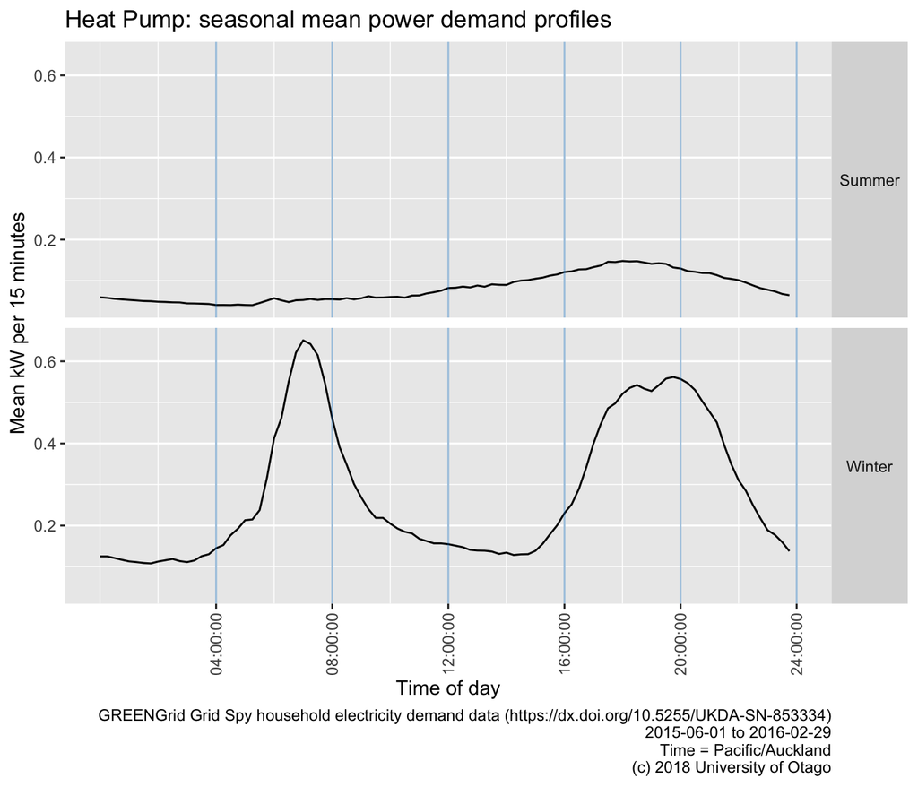

Figure 4.1: Demand profile plot

```r
gsDT <- gsDT[, r_dateTimeQHour := lubridate::floor_date(r_dateTime, unit = "15 mins")]

# create mean power across 15 minute periods to use as base dataset (comparable to SAVE)
qHourDT <- gsDT[, .(meanW = mean(powerW)), keyby = .(r_dateTimeQHour,linkID, season)
             ]
qHourDT <- qHourDT[, obsQHour := hms::as.hms(r_dateTimeQHour)]

plotDT <- qHourDT[, .(meanW = mean(meanW)), keyby = .(season, obsQHour)
             ]

# set attributes for plot
vLineAlpha <- 0.4
vLineCol <- "#0072B2" # http://www.cookbook-r.com/Graphs/Colors_(ggplot2)/#a-colorblind-friendly-palette
timeBreaks <- c(hms::as.hms("04:00:00"),
                hms::as.hms("08:00:00"),
                hms::as.hms("12:00:00"),
                hms::as.hms("16:00:00"),
                hms::as.hms("20:00:00"),
                hms::as.hms("24:00:00")
)

# create default caption
myCaption <- paste0("GREENGrid Grid Spy household electricity demand data (https://dx.doi.org/10.5255/UKDA-SN-853334)",
                        "\n", min(lubridate::date(gsDT$r_dateTime)),
                        " to ", max(lubridate::date(gsDT$r_dateTime)),
                        "\nTime = Pacific/Auckland",
                        "\n (c) ", lubridate::year(now())," University of Otago")

myPlot <- ggplot2::ggplot(plotDT[!is.na(season)], # make sure no un-set seasons/non-parsed dates
                          aes(x = obsQHour, y = meanW/1000)) +
  geom_line() +
  facet_grid(season ~ .) +
  scale_colour_manual(values=ggParams$cbPalette) + # use colour-blind friendly palette
  theme(strip.text.y = element_text(angle = 0, vjust = 0.5, hjust = 0.5)) +
  theme(axis.text.x = element_text(angle = 90, vjust = 0.5, hjust = 0.5)) +
  guides(colour = guide_legend(title = "Season: ")) +
  theme(legend.position = "bottom")  +
  labs(title = paste0(params$circuit, ": seasonal mean power demand profiles"),
       y = "Mean kW per 15 minutes",
       x = "Time of day",
       caption = myCaption
       )

myPlot +
  scale_x_time(breaks = timeBreaks) +
  geom_vline(xintercept = timeBreaks, alpha = vLineAlpha, colour = vLineCol)
```

```r
#ggplot2::ggsave(paste0(ggParams$repoLoc,"/examples/outputs/", params$circuit, "_meankWperminBySeason.png"))
```

Figure 4.1 shows the overall mean kW per minute in each season for this circuit (Heat Pump).

## 4.2 Profiles by linked household attributes

### 4.2.1 Number of people

Table 4.1 shows the number of households who have different numbers of people (children and adults). This table includes households where we do not know the number of people (NA) but we do have electricity demand data.

Table 4.1: Number of households with number of persons (full data)

| Q57 | Freq |
| --- | --- |
| NA | 2 |
| 1 | 4 |
| 2 | 11 |
| 3 | 10 |
| 4 | 10 |
| 5 | 5 |
| 6 | 2 |

Clearly this is too fine grained (too many categories). We therefor collapse to form the coding shown in 4.2.

Table 4.2: Number of households with number of persons (recoded)

| nPeople | Freq |
| --- | --- |
| NA | 2 |
| 1 | 4 |
| 2 | 11 |
| 3 | 10 |
| 4+ | 17 |

Now we link (join) the Grid Spy and household data.tables and aggregate (summarise) by season and number of people. You can do this using `data.table`’s on the fly [join](https://cran.r-project.org/web/packages/data.table/vignettes/datatable-faq.html#MergeDiff) but we have found pre-joining of the columns you want to be much faster. We’re not sure why as it shouldn’t be. You can probably also do this in `dplyr` etc but we haven’t tried.

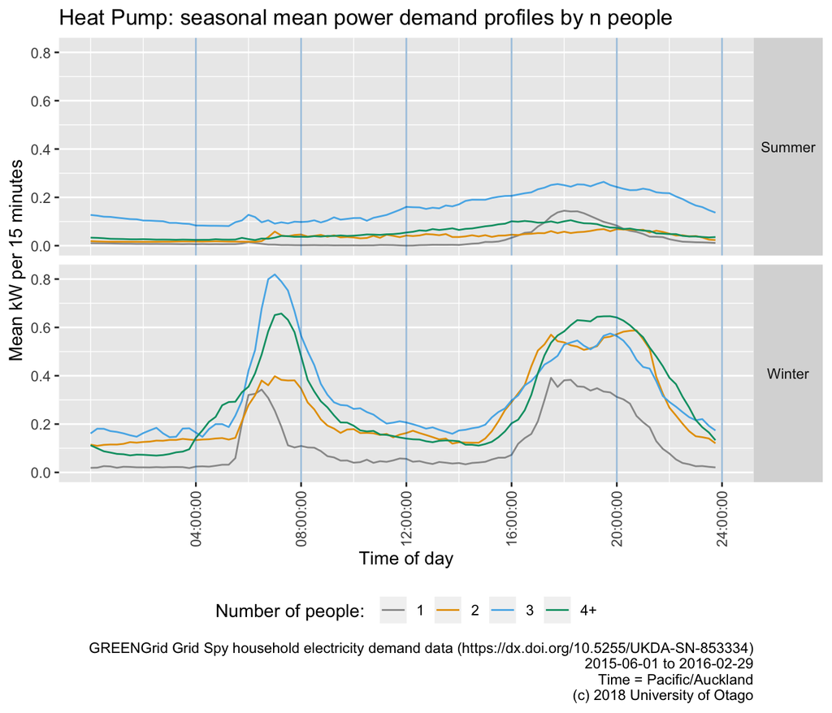

Figure 4.2: Demand profile plot - n people

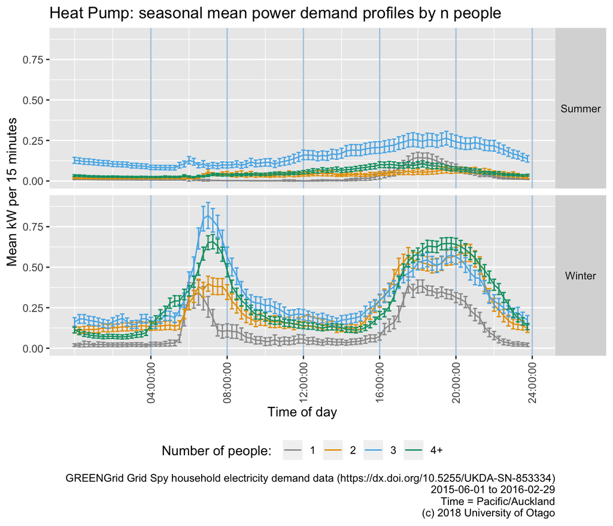

Figure 4.2: Demand profile plot - n people

Table 4.3: Actual n households used in plot

| nPeople | nHHs |
| --- | --- |
| 1 | 2 |
| 2 | 4 |
| 3 | 8 |
| 4+ | 12 |

### 4.2.2 Number of children

This section plots overall mean power per minute by season and number of children aged 0-12 as an illustration of how to link the Grid Spy and household data. We will go through the steps with commentary and showing the code…

Table 4.4 shows the number of households who have different numbers of children aged 0-12 so we know how many households make up each line on the plot. This table includes households where we do not know the number of children (NA) but we do have electricity demand data.

Table 4.4: Number of households with children aged 0-12

| nChildren0_12 | Freq |
| --- | --- |
| NA | 2 |
| 0 | 17 |
| 1 | 11 |
| 2 | 10 |
| 3 | 4 |

Table 4.4: Number of households with 1+ child aged 0-12

| presenceChildren | Freq |
| --- | --- |
| 0 children | 19 |
| 1+ child | 25 |

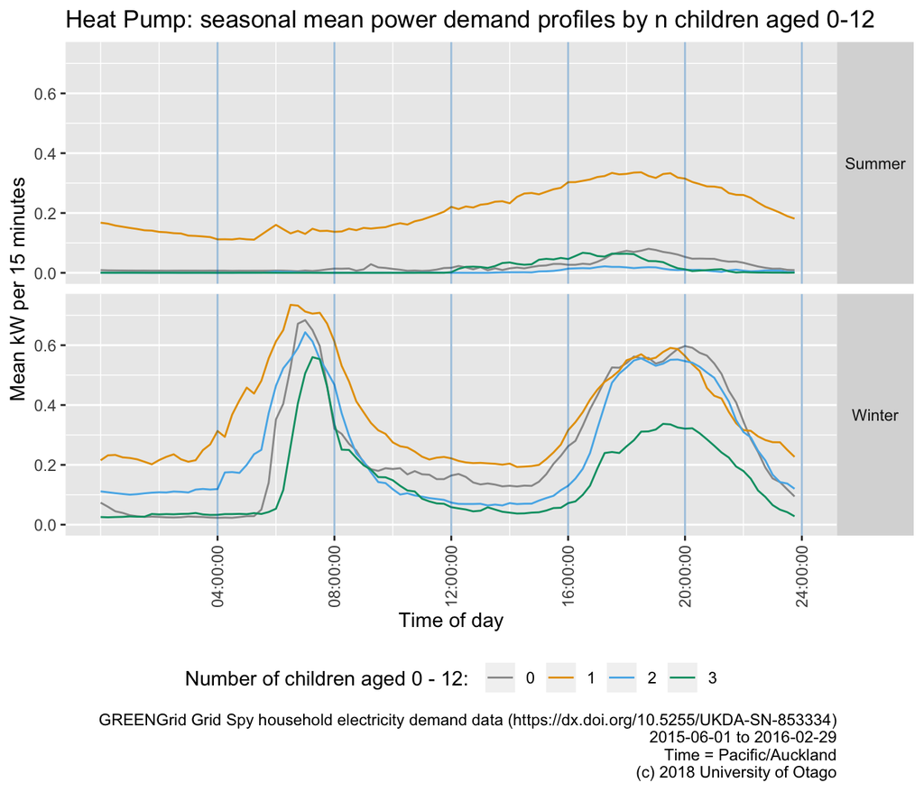

Figure 4.3: Demand profile plot - n kids

```r
keepCols <- c("linkID", "nChildren0_12")
mergedDT <- qHourDT[hhDT[, ..keepCols]]
plotDT <- mergedDT[!is.na(nChildren0_12), .(meanW = mean(meanW),
                                      sdW = sd(meanW),
                                      nObs = .N), keyby = .(season, obsQHour, nChildren0_12)]

plotDT <- plotDT[, ci_upper := meanW + qnorm(0.975)*(sdW/sqrt(nObs))]
plotDT <- plotDT[, ci_lower := meanW - qnorm(0.975)*(sdW/sqrt(nObs))]

basePlot <- ggplot2::ggplot(plotDT[!is.na(season)], # make sure no un-set seasons/non-parsed dates
                          aes(x = obsQHour, y = meanW/1000,
                              colour = as.factor(nChildren0_12))) +
  geom_line() +
  scale_colour_manual(values=ggParams$cbPalette) + # use colour-blind friendly palette
  facet_grid(season  ~ .) +
  theme(strip.text.y = element_text(angle = 0, vjust = 0.5, hjust = 0.5)) +
  theme(axis.text.x = element_text(angle = 90, vjust = 0.5, hjust = 0.5)) +
  guides(colour = guide_legend(title = "Number of children aged 0 - 12: ")) +
  theme(legend.position = "bottom")  +
  labs(title = paste0(params$circuit, ": seasonal mean power demand profiles by n children aged 0-12"),
       y = "Mean kW per 15 minutes",
       x = "Time of day",
       caption = myCaption
       )

basePlot <- basePlot +
  scale_x_time(breaks = timeBreaks) +
  geom_vline(xintercept = timeBreaks, alpha = vLineAlpha, colour = vLineCol)

basePlot
```

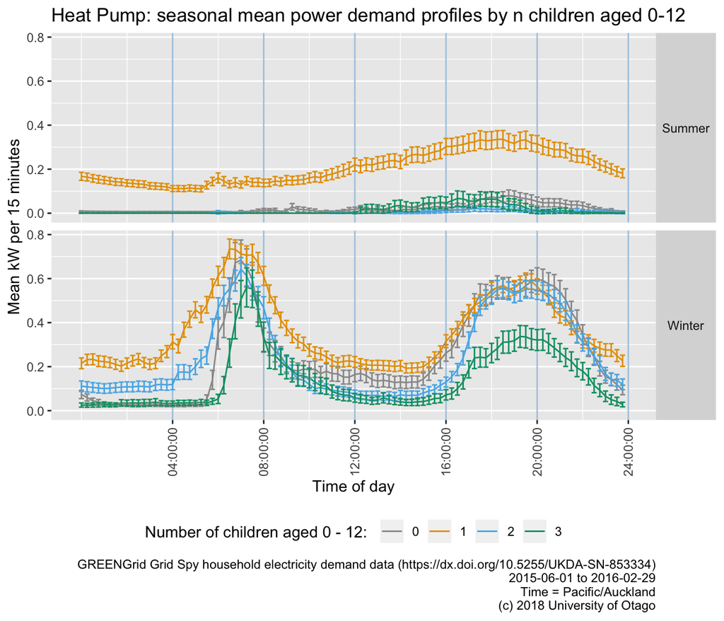

Figure 4.3: Demand profile plot - n kids

```r
# add 95% CI

ciPlot <- basePlot + geom_errorbar(aes(ymin = ci_lower/1000, ymax = ci_upper/1000))
ciPlot
```

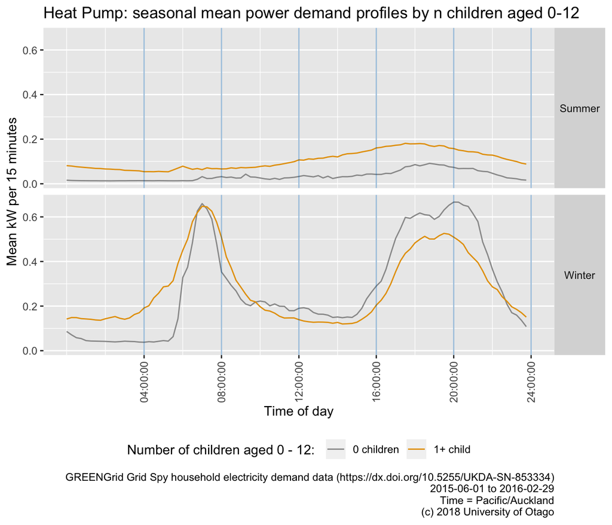

Figure 4.3: Demand profile plot - n kids

```r
# use reduced
keepCols <- c("linkID", "presenceChildren")
mergedDT <- qHourDT[hhDT[, ..keepCols]]
plotDT <- mergedDT[!is.na(presenceChildren), .(meanW = mean(meanW),
                                      sdW = sd(meanW),
                                      nObs = .N), keyby = .(season, obsQHour, presenceChildren)]

plotDT <- plotDT[, ci_upper := meanW + qnorm(0.975)*(sdW/sqrt(nObs))]
plotDT <- plotDT[, ci_lower := meanW - qnorm(0.975)*(sdW/sqrt(nObs))]

basePlot <- ggplot2::ggplot(plotDT[!is.na(season)], # make sure no un-set seasons/non-parsed dates
                          aes(x = obsQHour, y = meanW/1000,
                              colour = as.factor(presenceChildren))) +
  geom_line() +
  scale_colour_manual(values=ggParams$cbPalette) + # use colour-blind friendly palette
  facet_grid(season  ~ .) +
  theme(strip.text.y = element_text(angle = 0, vjust = 0.5, hjust = 0.5)) +
  theme(axis.text.x = element_text(angle = 90, vjust = 0.5, hjust = 0.5)) +
  guides(colour = guide_legend(title = "Number of children aged 0 - 12: ")) +
  theme(legend.position = "bottom")  +
  labs(title = paste0(params$circuit, ": seasonal mean power demand profiles by n children aged 0-12"),
       y = "Mean kW per 15 minutes",
       x = "Time of day",
       caption = myCaption
       )

basePlot <- basePlot +
  scale_x_time(breaks = timeBreaks) +
  geom_vline(xintercept = timeBreaks, alpha = vLineAlpha, colour = vLineCol)

basePlot
```

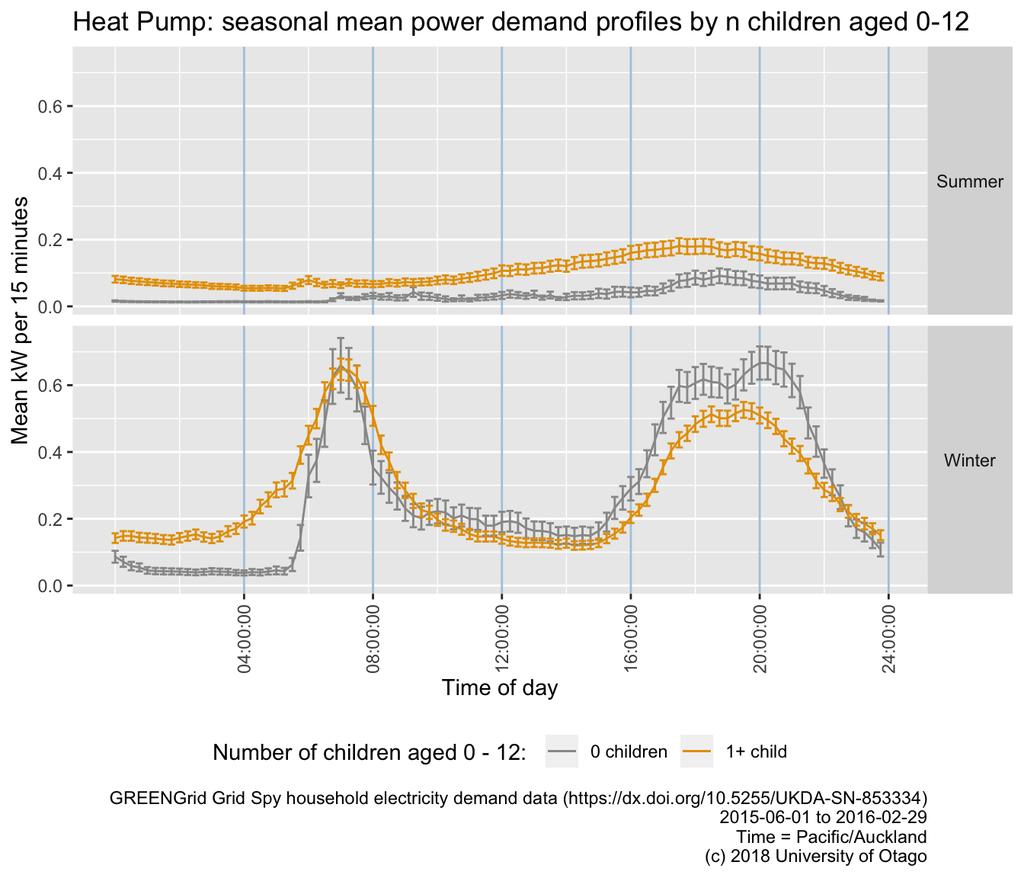

Figure 4.3: Demand profile plot - n kids

```r
# add 95% CI

ciPlot <- basePlot + geom_errorbar(aes(ymin = ci_lower/1000, ymax = ci_upper/1000))
ciPlot
```

```r
# actual n household used
t <- mergedDT[!is.na(presenceChildren) & !is.na(season) , .(nHHs = uniqueN(linkID)), keyby = .(presenceChildren)]

knitr::kable(t, caption = "Actual n households used in plot")
```

Table 4.5: Actual n households used in plot

| presenceChildren | nHHs |
| --- | --- |
| 0 children | 8 |
| 1+ child | 20 |

Figure 4.3 shows the mean kW per minute per season by presence of young children for this circuit (Heat Pump). Can you see anything interesting or unusual and might this be due to the numbers of households in each group?

# 5 Runtime

Analysis completed in 62.5 seconds ( 1.04 minutes) using knitr in [RStudio](http://www.rstudio.com) with R version 3.5.1 (2018-07-02) running on x86_64-apple-darwin15.6.0.

# 6 R environment

## 6.1 R packages used

# References

Allaire, JJ, Yihui Xie, Jonathan McPherson, Javier Luraschi, Kevin Ushey, Aron Atkins, Hadley Wickham, Joe Cheng, and Winston Chang. 2018. *Rmarkdown: Dynamic Documents for R*. https://CRAN.R-project.org/package=rmarkdown.

Anderson, Ben, and David Eyers. 2018. *GREENGridData: Processing Nz Green Grid Project Data to Create a ’Safe’ Version for Data Archiving and Re-Use*. https://github.com/CfSOtago/GREENGridData.

Csárdi, Gábor, and Rich FitzJohn. 2016. *Progress: Terminal Progress Bars*. https://CRAN.R-project.org/package=progress.

Dowle, M, A Srinivasan, T Short, S Lianoglou with contributions from R Saporta, and E Antonyan. 2015. *Data.table: Extension of Data.frame*. https://CRAN.R-project.org/package=data.table.

Grolemund, Garrett, and Hadley Wickham. 2011. “Dates and Times Made Easy with lubridate.” *Journal of Statistical Software* 40 (3): 1–25. http://www.jstatsoft.org/v40/i03/.

R Core Team. 2016. *R: A Language and Environment for Statistical Computing*. Vienna, Austria: R Foundation for Statistical Computing. https://www.R-project.org/.

Wickham, Hadley. 2007. “Reshaping Data with the reshape Package.” *Journal of Statistical Software* 21 (12): 1–20. http://www.jstatsoft.org/v21/i12/.

Wickham, Hadley, and Jennifer Bryan. 2017. *Readxl: Read Excel Files*. https://CRAN.R-project.org/package=readxl.

Wickham, Hadley, and Romain Francois. 2016. *Dplyr: A Grammar of Data Manipulation*. https://CRAN.R-project.org/package=dplyr.

Wickham, Hadley, Jim Hester, and Romain Francois. 2016. *Readr: Read Tabular Data*. https://CRAN.R-project.org/package=readr.

Xie, Yihui. 2016a. *Bookdown: Authoring Books and Technical Documents with R Markdown*. Boca Raton, Florida: Chapman; Hall/CRC. https://github.com/rstudio/bookdown.

———. 2016b. *Knitr: A General-Purpose Package for Dynamic Report Generation in R*. https://CRAN.R-project.org/package=knitr.

Zhu, Hao. 2018. *KableExtra: Construct Complex Table with ’Kable’ and Pipe Syntax*. https://CRAN.R-project.org/package=kableExtra.